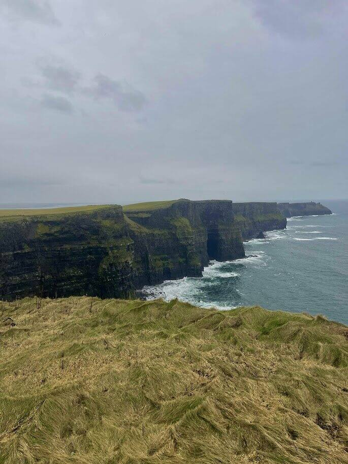

Personally Validated Framework

# Dublin *&* Galway

35+ pubs. One week. Both Lads were there.

35+Pubs Visited

6-7Days

3Windows

Quick Read

## Dublin + Galway at a glance

Both Lads have done this trip. 35+ pubs in Ireland in one week. 30 rated spots in Dublin, 15 in Galway (100% validated). Three timing windows — Christmas is the one we know best. Galway is the quieter half and worth every minute. The Cliffs of Moher day trip from Galway is non-negotiable.

The Framework

This is not a guide built from research. Both Lads completed this exact trip at Christmas—35+ pubs across Dublin and Galway in under a week. The personal experience is the primary source. Research covers two additional timing windows and fills the gaps.

Ireland rewards the group that plans around pub sessions, not monuments. The sights are worth doing, but they exist to earn the pint that follows. The pub is the destination. Everything else is the route there.

Both Lads Know This

Christmas. Every time. The pubs are full of people who actually live there. Seventy percent local crowd, fire-lit snugs, and the best trad music sessions of any window.

Three Timing Windows

| Feature | Christmas | St. Patrick’s | Summer |
| --- | --- | --- | --- |
| Atmosphere | Cozy, fire-lit, local | Chaotic, global spectacle | Bohemian, artistic |
| Crowd Mix | 70% local | 80% tourist | 50/50 |
| Pub Experience | Snugs, warm sessions | Standing room only | Outdoor, live gigs |
| Price Tier | Moderate | Highest | High |
| Primary Draw | Wren Day, markets | Parade, After Dark | Heineken Big Top |
| Verdict | Best for this group | Energy yes, crowds no | Worth it for GIAF |

### Christmas — The Personally Validated Window

What both Lads did. Late December. Many Irish people living abroad return home, creating reunion energy in local pubs that no other timing window replicates. Dublin Castle hosts a Christmas Market in the historic courtyard. Galway’s Eyre Square Market runs through December 31 with 50+ wooden chalets, a 32-meter Big Wheel, and a German Bier Keller.

December 25 is a full closure—everything shuts. Build around it. December 26 is St. Stephen’s Day (Wren Day), which is massive in the west. Wrenboy parades in straw costumes, pub sessions from noon to midnight, and the specific energy of a country celebrating together.

### St. Patrick’s Day — The Global Spectacle

The St. Patrick’s Festival in Dublin is now a four-day international event. 500,000 people line the streets. After Dark concerts run March 14–16. The pubs are standing room only and the crowd is 80% tourist. Getting a seat at The Long Hall becomes nearly impossible.

Galway is substantially better in this window—smaller crowds, more local feel. Consider basing in Galway and doing one day in Dublin for the parade. Book accommodation 9–12 months out. Flights from ORD run $900–1,300.

### Summer — Galway Arts Festival

July 13–26, 2026. The Heineken Big Top at Nimmo’s Pier hosts major acts—confirmed headliners include James, The Flaming Lips, and the Saw Doctors. Roisin Dubh and Monroe’s run official festival gigs.

The Week

| Day | Anchor | Key Stops |
| --- | --- | --- |
| Friday | Dublin Arrival | Lark Inn, Ginger Man, Christ Church area |
| Saturday | Dublin Sights | Trinity, St Patrick’s, Dublin Castle, The Long Hall |
| Sunday | Day Trip | Wicklow/Glendalough or Kilkenny Castle |
| Monday | Howth + Guinness | DART to Howth, cliff walk, Storehouse, Brazen Head |
| Tuesday | Train to Galway | Irish Rail, Latin Quarter, Taaffes, Tig Coili |
| Wednesday | Cliffs of Moher | Burren, Hazel Mountain Chocolate, evening pints |
| Thursday | Galway + Depart | Morning wander, Garavans for a final pint |

Both Lads Know This

We did 35+ pubs in 6–7 days. A week is enough if you move with purpose. Two days Dublin, one day trip, train to Galway, two days Galway, one Cliffs day trip. That is the week.

The Temple Bar Warning

Temple Bar looks like Ireland. It is not Ireland. Walk 12 minutes to Stoneybatter or stay in the Liberties and pay half price for an identical pint in a better pub with a better crowd.

Temple Bar Pub€10.45/pint

Stoneybatter local€5.50/pint

For a group of 8, drinking in Temple Bar costs over €20 per person per night in wasted spend.

Dublin Pub Guide

[figure not shown]

The Must-Hit Tier

The Cobblestone

4.7★ · €10–20

Smithfield. Best trad pub in Dublin. Locals fought a development to protect it. Arrive before 9pm for a seat.

John Kavanagh — The Gravediggers

4.7★ · €10–20

Near Glasnevin Cemetery. Unchanged for 150 years. Worth the trip from the centre.

Darkey Kelly’s

4.7★ · €20–30

Fishamble Street. Historic, excellent reviews, high energy.

The Long Hall

4.6★ · €10–20

Victorian interior. One of Dublin’s most beautiful pubs. Dark wood, high ceilings. Slow pint territory.

Both Lads Visited

O’Donoghues Bar

4.6★

Legendary trad music. The Dubliners started here — one of the most important pubs in Irish traditional music.

Both Lads Visited

The Celt

4.6★ · €20–30

Live trad music nightly. Tourist-friendly but genuinely good sessions.

The Lark Inn

4.6★

The arrival ritual. Toasties and cheap pints to decompress from the journey. No pretense, exactly right for day one.

Both Lads · Arrival Ritual

The Lads Pick Tier

The Ginger Man

4.5★ · €10–20

Favourite pub in Dublin among the Lads. More local crowd. The kind of place you go back to.

Lads Favourite

[figure not shown]

The Brazen Head

4.5★ · €20–30

Oldest pub in Ireland, established 1198. Touristy but unmissable. History in a glass.

Both Lads Visited

Kehoe’s

4.5★ · €10–20

Victorian snug pub on South Anne Street. Fireplace and a perfectly poured pint.

Mulligan’s

€€

Best Guinness in Dublin. Poolbeg Street. No frills. Perfect pint.

The Stag’s Head

4.5★ · €10–20

Victorian. One of Dublin’s most photogenic bars. Stained glass and dark wood.

The Dawson Lounge

4.5★ · €1–10

Smallest pub in Dublin. A must for novelty alone.

Both Lads Visited

Grogan’s

4.5★ · €10–20

Artist pub. Cheap pints, no music. Bohemian crowd.

Also in the Database

O’Neills

4.5★ · €10–20

Large, good energy. Became the designated Jager bomb stop.

Both Lads Visited

The Blind Pig Speakeasy

4.4★ · €€€

Prohibition-style speakeasy. Good for a one-off cocktail night.

Bunsen

€€

Best burgers in Dublin. Simple menu. Hit this for at least one lunch.

Dublin Sights

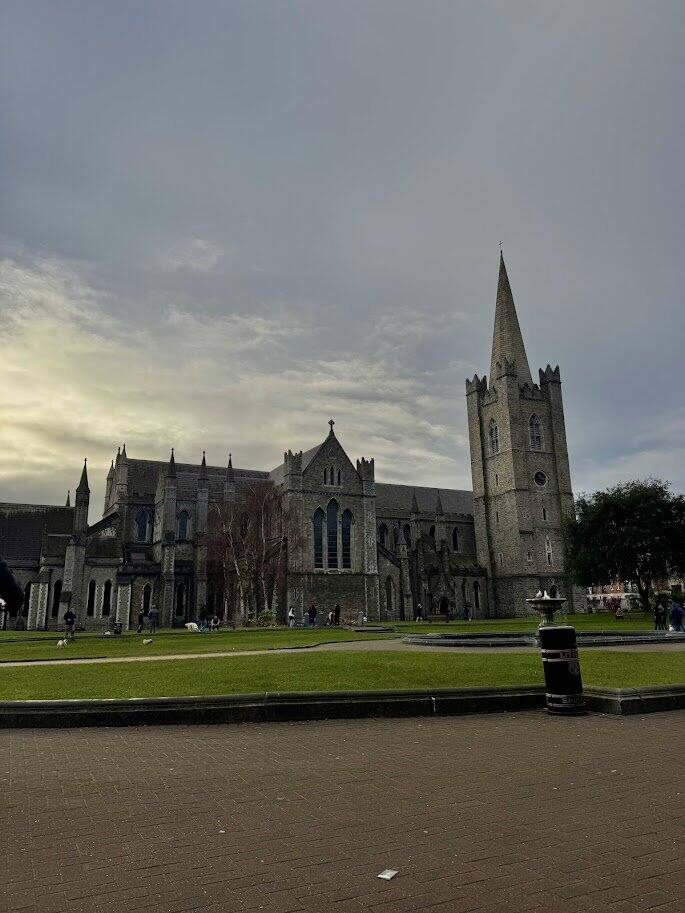

Both Lads Know This

The sights are genuinely worth doing. St Patrick’s Cathedral, Trinity College, Dublin Castle—these are not tourist traps, they are the city’s actual bones.

Trinity College — The Long Room

4.6★ · €14+

The Long Room library is extraordinary. One of the most photographed rooms in Europe.

Guinness Storehouse

4.4★ · €26+

Gravity Bar pint with 360-degree views. Get the Stoutie—your face printed on a Guinness.

Both Lads · Must Do

St Patrick’s Cathedral

4.5★ · €8

Ireland’s largest cathedral. Jonathan Swift’s tomb.

Kilmainham Gaol

4.7★ · €8

Where the 1916 Rising leaders were executed. Essential.

Dublin Castle

4.3★ · €8

Former seat of British rule. Gardens are free.

Galway Pub Guide

Every pub on this list is worth visiting. Both Lads loved every spot in Galway without qualification. The hit rate is higher than Dublin.

Both Lads Know This

The Galway pub list is shorter than Dublin but the hit rate is higher. Every single one of these is worth your time. Go to all of them if the night cooperates.

Tig Coili

4.7★ · €10–20

Best trad music sessions in Galway. Pack in early—seats disappear by 8pm.

Both Lads Visited

O’Connell’s Bar

4.7★ · €10–20

One of Galway’s best traditional pubs. Nearly 3,000 reviews at 4.7 stars.

Both Lads Visited

Taaffes Bar

4.6★ · €1–10

Trad music, cheap pints. Original Galway pick. Both Lads returned a second time the same night.

Both Lads · Went Back Twice

Tigh Neachtain

4.6★ · €10–20

Classic Galway pub. Outdoor seating on Quay Street. Colourful exterior.

Lads’ Galway Pick

Garavan’s Bar

4.6★ · €10–20

No music. Great pints, good conversation. The right final pint of the trip.

Both Lads Visited

Barr An Chaladh

4.6★ · €10–20

Docks area. Quieter pint away from the main strip. Good for landing in Galway.

Both Lads Visited

The Kings Head

4.4★ · €20–30

Medieval building, live music. One of the most atmospheric rooms in the city.

Both Lads Visited

McGinn’s Hop House

4.5★ · €10–20

Gastropub with craft beer focus.

Both Lads Visited

Salt House

—

Very good. Pending database addition.

Both Lads Visited

Tigh Chinn

—

Very good. Pending database addition.

Both Lads Visited

The Dough Bros

4.7★ · €10–20

Best-reviewed restaurant in Galway. Worth a dinner stop.

Galway Sights

The Latin Quarter

4.6★ · Free

Medieval quarter. Best area to wander. This is where the pub circuit concentrates.

Galway Cathedral

4.6★ · Free

Worth a look if arriving by road.

Howth Cliff Walk

[figure not shown]

Howth Cliff Walk

4.9★ · Free

30 minutes by DART from Connolly or Tara Street. Coastal village, cliff walk with Atlantic views, seafood at the harbour, pint at McNeills at the trailhead. Rated 8/10 by the Lads.

Both Lads Know This

DART from city centre, 30 minutes. Walk the cliffs. Eat at the harbour. Pint at McNeills before the train back. That is the whole plan.

Wicklow & Kilkenny

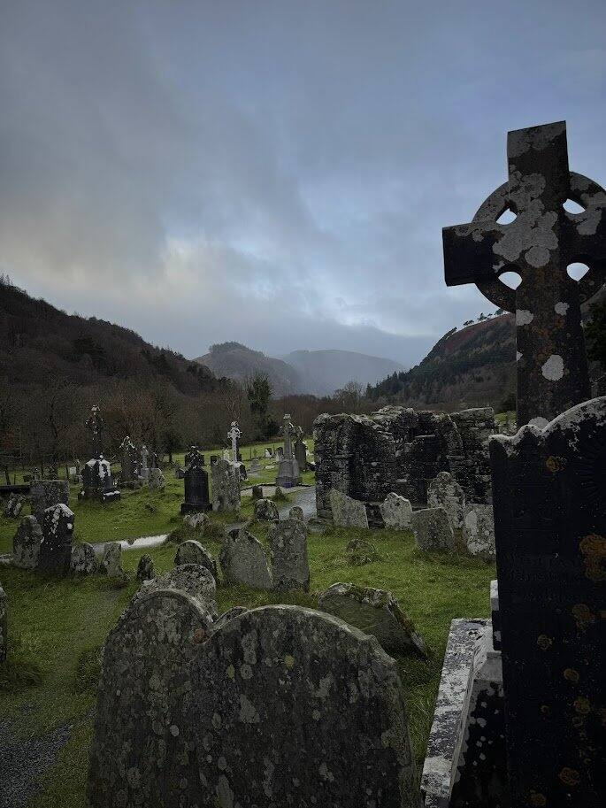

Wicklow Mountains National Park

4.8★ · Free

1 hour south of Dublin. Glendalough monastic ruins, lake, mountain scenery. Tour or rental car. Rated 8.5/10 by the Lads.

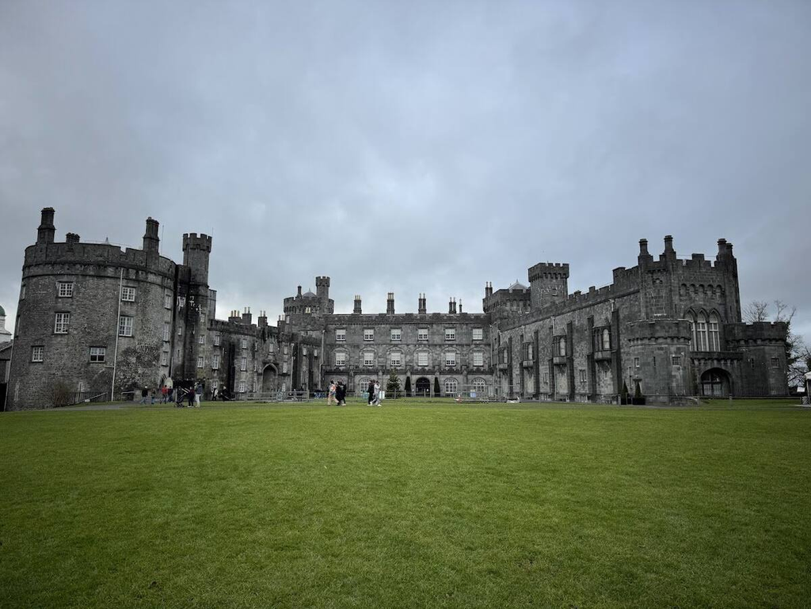

Kilkenny Castle & City

4.7★ · €8

1.5 hours from Dublin. Medieval castle, cobbled streets. Matt the Millers is the pub stop in Kilkenny.

[figure not shown]

Both Lads Know This

We did Wicklow and Kilkenny on the same trip. Both are worth it. Wicklow is the easier day; Kilkenny is the better full-day commitment.

The Lads took this full-day guided tour from Dublin:

[Viator — Glendalough, Wicklow & Kilkenny →](https://gyg.me/V0UrxNUe)

Cliffs of Moher & The Burren

Cliffs of Moher

4.7★ · €8

One of the most dramatic coastal sites in Europe. Day trip from Galway by tour. Rated 9/10 by the Lads.

The Burren

—

Lunar limestone landscape. Completely different from the rest of Ireland. Do not just drive through it.

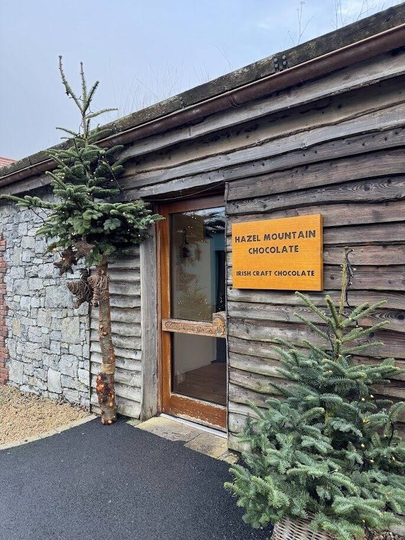

Hazel Mountain Chocolate

4.5★

Stop en route to the Cliffs. The chocolate is genuinely excellent.

Both Lads Know This

Go to the edge of the Cliffs. The wind will push back. The Burren is unlike anything else in Ireland. We did this in Christmas conditions—dramatic and excellent, just windy.

[Viator — Cliffs of Moher & Burren from Galway →](https://www.viator.com/tours/Galway/Cliffs-of-Moher-and-Burren-Day-Trip-Including-Dunguaire-Castle-Aillwee-Cave-and-Doolin-from-Galway/d5156-8625P1)

Flights

Recommended — ORD to DUB

Aer Lingus and United fly nonstop daily. 7 hours 15 minutes.

DTW

No nonstop to Dublin. Connections via JFK, BOS, or PHL add time and risk. ORD is worth the drive.

Alternative

Icelandair via Reykjavik (KEF)—viable if a stopover in Iceland makes sense for the group.

Dublin to Galway

The Call — Irish Rail

Approximately €45 per person. 2 hours 10 minutes. Comfortable, direct, and nobody has to drive.

Both Lads Know This

Getting Around

Howth

DART from Connolly or Tara Street. 30 minutes.

Wicklow / Glendalough

Tour operator or rental car. Not public-transport accessible.

Cliffs of Moher

Tour operator from Galway is the easier call for a group. Full day, driver handles navigation.

Urban

Uber works in Dublin. Taxis reliable in both cities. Walking is the default—both centres are compact.

Tipping

Tipping in Ireland is customary but not mandatory. Round up or leave a small amount. The US expectation of 20% does not apply. Do not tip as though you are in America.

Cost Model — Per Person, Group of 4

| Category | Christmas | St. Pat’s | Summer |
| --- | --- | --- | --- |
| Flights (ORD) | $850 | $1,100 | $1,200 |
| Accommodation (6 nights) | $600 | $900 | $750 |
| Dublin–Galway Train | $50 | $50 | $50 |
| Pub Spend (~€60/day) | $450 | $500 | $450 |
| Food (~€40/day) | $300 | $300 | $300 |
| Activities | $150 | $150 | $200 |
| Total (Standard) | $2,400 | $3,000 | $2,950 |

Lean scenario: ~$1,900 (Christmas). Hostel private dorms, Bus Eireann, €5 pints, grocery breakfasts.

What First-Timers Get Wrong

01

### Drinking in Temple Bar

€10.45 for a pint. Walk 12 minutes to Stoneybatter and pay €5.50. The atmosphere in a local pub is better.

02

### Assuming All Pubs Are the Same

The Cobblestone and a Temple Bar tourist pub are the same product in the same way a stadium hot dog and a proper meal are.

03

### Underestimating Galway

Every group goes to Dublin. Not every group makes it to Galway. The pub circuit is tighter, crowds more local, trad music better. Do not skip it.

04

### Tipping Like They’re in America

Round up. Do not leave 20%.

05

### Booking St. Patrick’s Day Late

9–12 months out. Accommodation fills and prices become unreasonable after that window.

06

### Skipping Howth

30 minutes by DART. Cliff walk, seafood, pint at McNeills. Rated 8/10. Most groups skip it. Take the DART.

Your Maps

## Google Maps Lists

Every spot in this framework, pinned and organized. Open on your phone when you land.

[Dublin Pubs & Food →](https://maps.app.goo.gl/NrZtg6tUR1Rjk8oS8) [Dublin Attractions →](https://maps.app.goo.gl/9YLakDkjrE6jj7cQA) [Galway →](https://maps.app.goo.gl/deRD11SQis6ZUsKL8)

The Lads Travel Co.

Personally validated trip planning across 20+ cities.

dangelobraden43@gmail.com